# RedNeuronalConTensorFlowKeras

## 14. COMPARACION ENTRE MODELO BASE Y MODELO OPTIMIZADO

```python
#Modelo Base
print('MODELO BASE')
nombreArchivoModelo='arquitectura_base'
nombreArchivoPesos='pesos_base'
Selectedmodel=cargarRNN(nombreArchivoModelo,nombreArchivoPesos)

#Selectedmodel.summary()

Selectedmodel.compile(loss='mse', optimizer='rmsprop', metrics=['mse','mae']) #ADADELTA: An Adaptive Learning Rate Method
print('Resultado en Train:')

score = Selectedmodel.evaluate(X_train, y_train, verbose=0)
print((Selectedmodel.metrics_names[1], score[1]))

#Fase de Testing
print('Resultado en Test:')
score = Selectedmodel.evaluate(X_test, y_test, verbose=0)
print((Selectedmodel.metrics_names[1], score[1]))

#Modelo optimizado
print('MODELO OPTIMIZADO')
nombreArchivoModelo='arquitectura_optimizada'
nombreArchivoPesos='pesos_optimizados'
Selectedmodel=cargarRNN(nombreArchivoModelo,nombreArchivoPesos)

#Selectedmodel.summary()

Selectedmodel.compile(loss='mse', optimizer='rmsprop', metrics=['mse','mae']) #ADADELTA: An Adaptive Learning Rate Method
print('Resultado en Train:')
score = Selectedmodel.evaluate(X_train, y_train, verbose=0)
print((Selectedmodel.metrics_names[1], score[1]))

#Fase de Testing
print('Resultado en Test:')
score = Selectedmodel.evaluate(X_test, y_test, verbose=0)
print((Selectedmodel.metrics_names[1], score[1]))
```

[output not shown]

```
dict_keys(['val_loss', 'val_mse', 'val_mae', 'loss', 'mse', 'mae'])
```

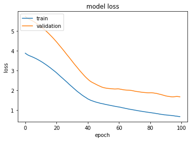

```python
#Graficos
#Visualización de accuracy
#Aqui se utiliza los resultados del modelo base para graficarlos y realizar una comparacion con el modelo optimizado
#Como podemos observar, el modelo base no sirve, el error es muy grande
print(history.history.keys())
# "Loss"
plt.plot(history.history['loss'])
plt.plot(history.history['val_loss'])
plt.title('model loss')
plt.ylabel('loss')
plt.xlabel('epoch')
plt.legend(['train', 'validation'], loc='upper left')
plt.show()
```

```
dict_keys(['val_loss', 'val_mse', 'val_mae', 'loss', 'mse', 'mae'])
```

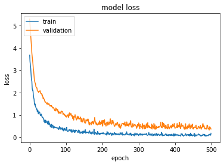

```python
#Graficos
#Visualización de accuracy
#Se grafica el modelo optimizado y se puede observar que el error ha bajado considerablemente
print(history2.history.keys())
# "Loss"
plt.plot(history2.history['loss'])
plt.plot(history2.history['val_loss'])
plt.title('model loss')
plt.ylabel('loss')
plt.xlabel('epoch')
plt.legend(['train', 'validation'], loc='upper left')
plt.show()
```

## 15. PREDICCION - USO DEL MODELO OPTIMIZADO

```python
cnames = ['motor', 'screw', 'pgain', 'vgaing']
data = [['D', 'B', 6, 5]]
my_X = pd.DataFrame(data=data, columns=cnames)
my_X = preprocesador1.transform(my_X)

print(my_X)
Xnew= scaler_x.transform(my_X)
ynew= Selectedmodel.predict(my_X)

print("X=%s, Predicted=%s" % (Xnew[0], ynew[0]))
```

```
[[1.81755995 1.80200772 0.         0.         0.         1.
  0.         0.         1.         0.         0.         0.        ]]
X=[1. 1. 0. 0. 0. 1. 0. 0. 1. 0. 0. 0.], Predicted=[0.47109544]
```

## CONCLUSIONES

El principal problema que suscito en esta practica con respecto a la anterior, fue al momento de optimizar el modelo, en la clasificacion se utiliza KERASCLASSIFIER, en este caso en cambio se ha utilizADO KERASREGRESSOR, esto nos permitio obtener un modelo mucho mejor que el modelo base, los resultados fueron los siguientes:

MODELO BASE:

MODELO OPTIMIZADO

Resultado en Train:

0.09669630974531174

Resultado en Test:

0.11443272233009338

El error que se utilizo fue MSE(Mean Square Error), mientras mas alto es este error, peor es la red neuronal. Aunque el requerimiento por parte del docente ha sido obtener el accuracy, no es posible esto, debido a que, la medicion mas aceptable para la Regression es MSE.

## REFERENCIAS

KERASREGRESSOR

https://www.tensorflow.org/api_docs/python/tf/keras/wrappers/scikit_learn/KerasRegressor

DATASET obtenido de:

https://archive.ics.uci.edu/ml/datasets/Servo

PARAMETROS de optimizacion

https://scikit-learn.org/stable/modules/grid_search.html#multimetric-grid-search